# common distributions

variables number of people love the colour blue == discrete value countable height of people == countinous

age == continous numeric age group (child, adult, senior) == ordinal categoric numer of people in house hold == discrete numeric heigh/weight == continuous numeric shoe size == continuous numeric vegetarian == nominal categoric (binary)

## probability mass and probability density function

discrete probability distribution is a probability distribution of a discrete variable

heads or tail, discrete number of outcomes

probability mass function -> prob distribution of a discrete variable

probability density function -> prob distribution of a continouse variabele

(what is the prob of heights in the range from 174.22cm - 178.91cm )

in the case of pmf and pdf while we can measure prob for specific discrete values of pmf we can’t for pdf

we look at the prob of a range of a values

rules for probabiliuty distributions

- outcome is our x
- y is probability of that outcome occuring (pmfs) -the sum of all prob must be 1
- each prob must be between 0 and 1

rules for continous probability distribution -outcome are still x - y = p(x) probability density - the area under the curve must be 1

```r
library(tidyverse)
```

```r
source('prob.R')
```

via cumulative distribution functions

F(1) = 1/6 F(2) = 1/6 + 1/6

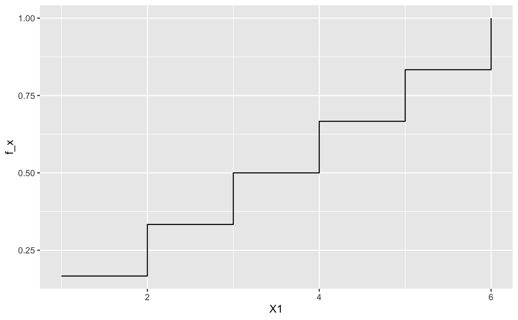

getting individual probability from cdfs p(3) = f(3) - f(2) = 0.5 - 0.33 = 0.16 p(4) = f(4) - f(3)

l is continuous

what will it look like?

useful distribution functions p - cumulative density function q - quantile r -random number d - distribution # the following gives you distribution

```r
dunif(x = seq(4, 23, 0.1), min = 5, max = 22)
```

```
  [1] 0.00000000 0.00000000 0.00000000 0.00000000 0.00000000 0.00000000 0.00000000
  [8] 0.00000000 0.00000000 0.00000000 0.05882353 0.05882353 0.05882353 0.05882353
 [15] 0.05882353 0.05882353 0.05882353 0.05882353 0.05882353 0.05882353 0.05882353
 [22] 0.05882353 0.05882353 0.05882353 0.05882353 0.05882353 0.05882353 0.05882353
 [29] 0.05882353 0.05882353 0.05882353 0.05882353 0.05882353 0.05882353 0.05882353
 [36] 0.05882353 0.05882353 0.05882353 0.05882353 0.05882353 0.05882353 0.05882353
 [43] 0.05882353 0.05882353 0.05882353 0.05882353 0.05882353 0.05882353 0.05882353
 [50] 0.05882353 0.05882353 0.05882353 0.05882353 0.05882353 0.05882353 0.05882353
 [57] 0.05882353 0.05882353 0.05882353 0.05882353 0.05882353 0.05882353 0.05882353
 [64] 0.05882353 0.05882353 0.05882353 0.05882353 0.05882353 0.05882353 0.05882353
 [71] 0.05882353 0.05882353 0.05882353 0.05882353 0.05882353 0.05882353 0.05882353
 [78] 0.05882353 0.05882353 0.05882353 0.05882353 0.05882353 0.05882353 0.05882353
 [85] 0.05882353 0.05882353 0.05882353 0.05882353 0.05882353 0.05882353 0.05882353
 [92] 0.05882353 0.05882353 0.05882353 0.05882353 0.05882353 0.05882353 0.05882353
 [99] 0.05882353 0.05882353 0.05882353 0.05882353 0.05882353 0.05882353 0.05882353
[106] 0.05882353 0.05882353 0.05882353 0.05882353 0.05882353 0.05882353 0.05882353
[113] 0.05882353 0.05882353 0.05882353 0.05882353 0.05882353 0.05882353 0.05882353
[120] 0.05882353 0.05882353 0.05882353 0.05882353 0.05882353 0.05882353 0.05882353
[127] 0.05882353 0.05882353 0.05882353 0.05882353 0.05882353 0.05882353 0.05882353
[134] 0.05882353 0.05882353 0.05882353 0.05882353 0.05882353 0.05882353 0.05882353
[141] 0.05882353 0.05882353 0.05882353 0.05882353 0.05882353 0.05882353 0.05882353
[148] 0.05882353 0.05882353 0.05882353 0.05882353 0.05882353 0.05882353 0.05882353
[155] 0.05882353 0.05882353 0.05882353 0.05882353 0.05882353 0.05882353 0.05882353
[162] 0.05882353 0.05882353 0.05882353 0.05882353 0.05882353 0.05882353 0.05882353
[169] 0.05882353 0.05882353 0.05882353 0.05882353 0.05882353 0.05882353 0.05882353
[176] 0.05882353 0.05882353 0.05882353 0.05882353 0.05882353 0.05882353 0.00000000
[183] 0.00000000 0.00000000 0.00000000 0.00000000 0.00000000 0.00000000 0.00000000
[190] 0.00000000 0.00000000
```

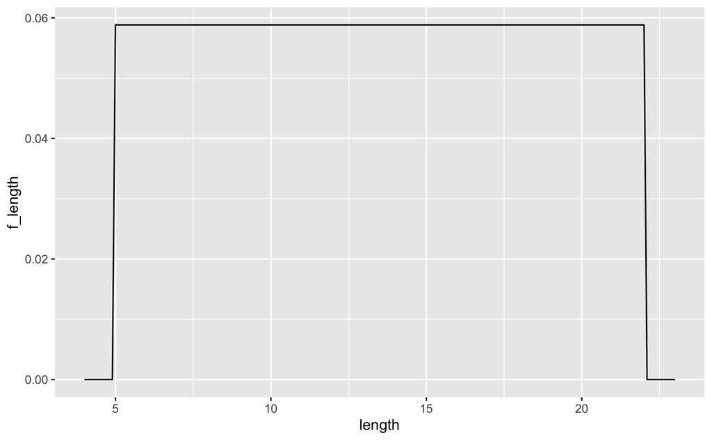

```r
brain_breaks <- tibble(
  length = seq(4, 23, 0.1),
  f_length = dunif(x = length, min = 5, max = 22)
)

brain_breaks %>%
  ggplot(aes(x = length, y = f_length))+
  geom_line()
```

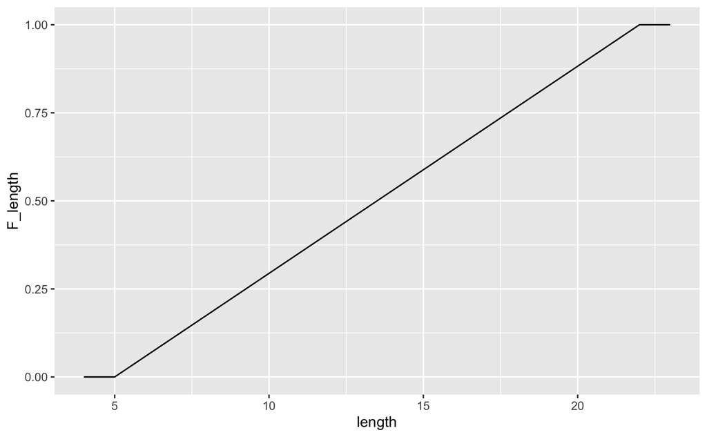

```r
brain_breaks %>%
  mutate(F_length = punif(q = length, min = 5, max = 22)) %>%
  ggplot(aes(x = length, y = F_length))+
  geom_line()
```

what is the prob of a brain break between 8.4 and 10.7? f(10.7) - f(8.4)

```r
f_10_7 <- punif(
  q = 10.7, min = 5, max = 22
)

f_8_4 <-punif(
  q = 8.4, min = 5, max = 22
)

f_10_7 - f_8_4
```

```
[1] 0.1352941
```

what does it look like on plot

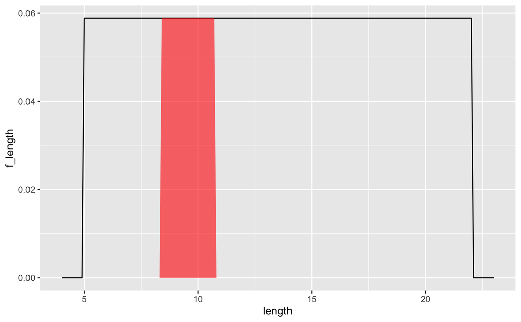

```r
brain_breaks %>%
  ggplot(aes(x = length, y = f_length))+
  geom_line()+
  geom_ribbon(aes(ymin = 0, ymax = ifelse(
    length >= 8.4 & length <= 10.7, f_length, 0)),
    fill = "red", alpha = 0.6)
```

```r
(10.7 - 8.4) * max(brain_breaks$f_length)
```

```
[1] 0.1352941
```

normal distribution

```r
three_norm <- tibble(
  x = seq(0, 100, 1),
  f1_x = dnorm(x = x, mean = 50, sd = 10),
  f2_x = dnorm(x = x, mean = 50, sd = 20),
  f3_x = dnorm(x = x, mean = 50, sd = 30)
)
```

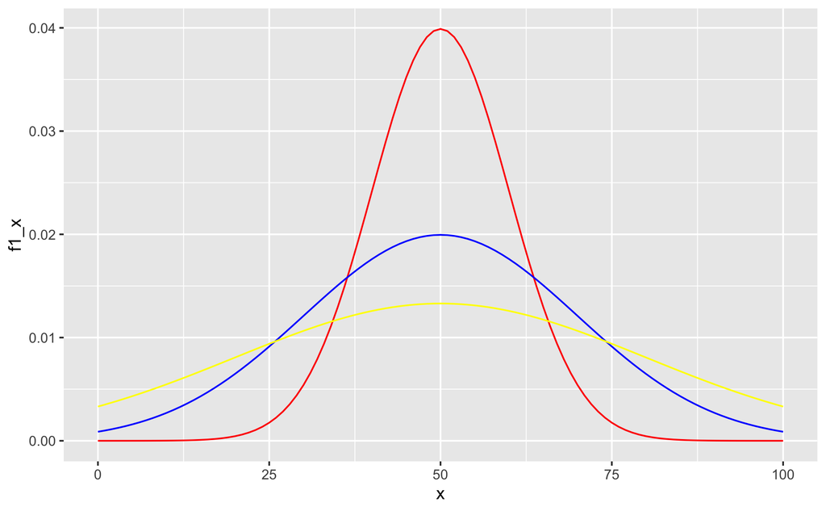

```r
three_norm %>%
  ggplot()+
  geom_line(aes( x, f1_x), col = 'red')+
  geom_line(aes( x, f2_x), col = 'blue')+
  geom_line(aes( x, f3_x), col = 'yellow')
```

```r
library(janitor)
```

```r
jobs <- read_csv("data/TyrellCorpJobs.csv") %>%
  clean_names()
```

```r
accounts_salary_stats <- jobs %>%
  filter(position == "Accounting") %>%
  summarise(
    num = n(),
    mean = mean(salary),
    sd = sd(salary)
  )
accounts_salary_stats
```

| num | mean | sd |
| --- | --- | --- |
| 120 | 34115.02 | 2383.676 |

plot the histogram change the meric of the histogram with aes(y = ..density..) use stat function and pre_calculated stats to overlay a normal distrubution

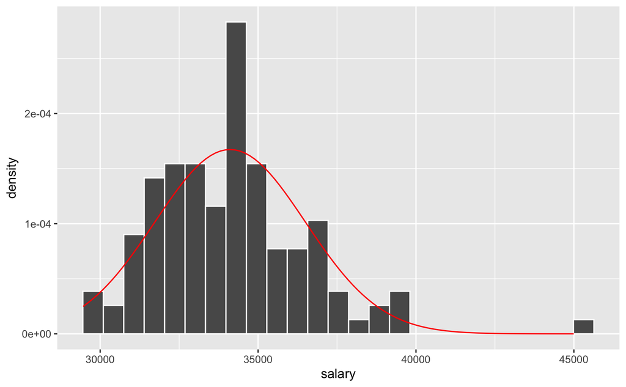

```r
jobs %>%
  filter(position == "Accounting") %>%
  ggplot(aes(x = salary)) +
  geom_histogram(aes(y = ..density..), col = "white", bins = 25) +
  stat_function(
    fun = dnorm,
    args = list(
      mean = accounts_salary_stats$mean,
      sd = accounts_salary_stats$sd
    ),
    col = "red"
  )
```

qqplot quantile plots normality test look at a normal distribution vs our data fitting a normal distribution to data set

standard normal scaled so that the mean = 0, sd = 1 standarised variable (too to describe normal distributions) z = x - xbar / s

z = 1.3 then the value is 1.3 * sd away from the mean value z = 3 would be 3 * sd …….

another def of outlier any value of z above 3 1.5 iqr away from q 3 or q1

```r
management_scaled <- jobs %>%
  filter(position == "Management") %>%
  # scale automaticlly calculates z score
  mutate(z_salary = scale(salary)) %>%
  mutate(mean_sl = mean(salary))

management_scaled
```

| x1 | position | salary | z_salary | mean_sl |
| --- | --- | --- | --- | --- |
| 3 | Management | 50036 | -0.076791849 | 50876.15 |
| 9 | Management | 57823 | 0.634963626 | 50876.15 |
| 14 | Management | 60180 | 0.850400592 | 50876.15 |
| 18 | Management | 52290 | 0.129230604 | 50876.15 |
| 19 | Management | 44425 | -0.589654308 | 50876.15 |
| 22 | Management | 42971 | -0.722554329 | 50876.15 |
| 23 | Management | 67832 | 1.549816657 | 50876.15 |
| 27 | Management | 64078 | 1.206689644 | 50876.15 |
| 28 | Management | 33849 | -1.556332863 | 50876.15 |
| 41 | Management | 55649 | 0.436253417 | 50876.15 |

[output cut: 45 more lines]

```r
management_scaled %>%
  filter(!between(z_salary, left = -3, right = 3))
```

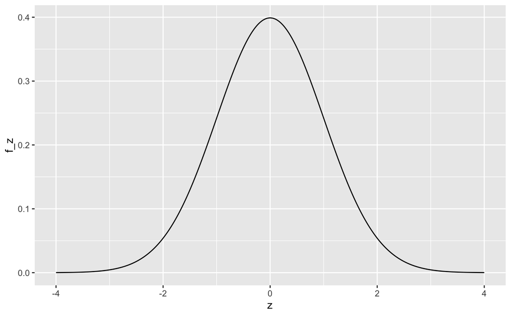

```r
standard_normal <- tibble(
  z = seq(from = -4, to = 4, by = 0.01),
  f_z = dnorm(x = z)
)

standard_normal %>%
  ggplot(aes(x = z, y = f_z)) +
  geom_line()
```

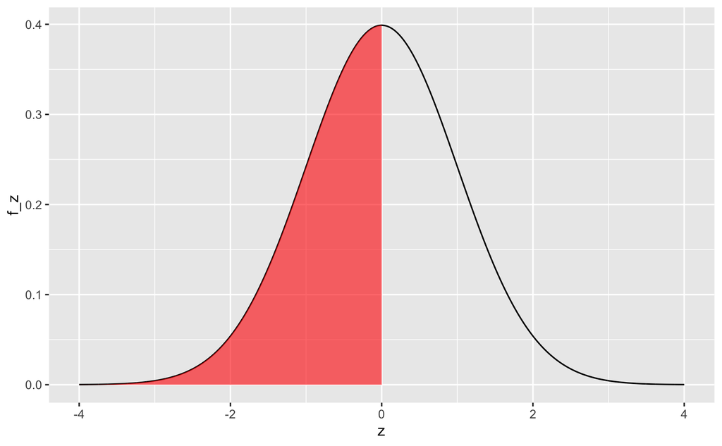

```r
shade_standard_normal <- function(shade_from, shade_to){
  standard_normal <- tibble(
    z = seq(from = -4, to = 4, by = 0.001),
    f_z = dnorm(x = z)
  )
  standard_normal %>%
    ggplot(aes(x = z, y = f_z)) +
    geom_line() +
    geom_ribbon(aes(ymin = 0, ymax = ifelse(z >= shade_from & z <= shade_to, f_z, 0)), fill = "red", alpha = 0.6)
}

shade_standard_normal(shade_from = -Inf, shade_to = 0)
```

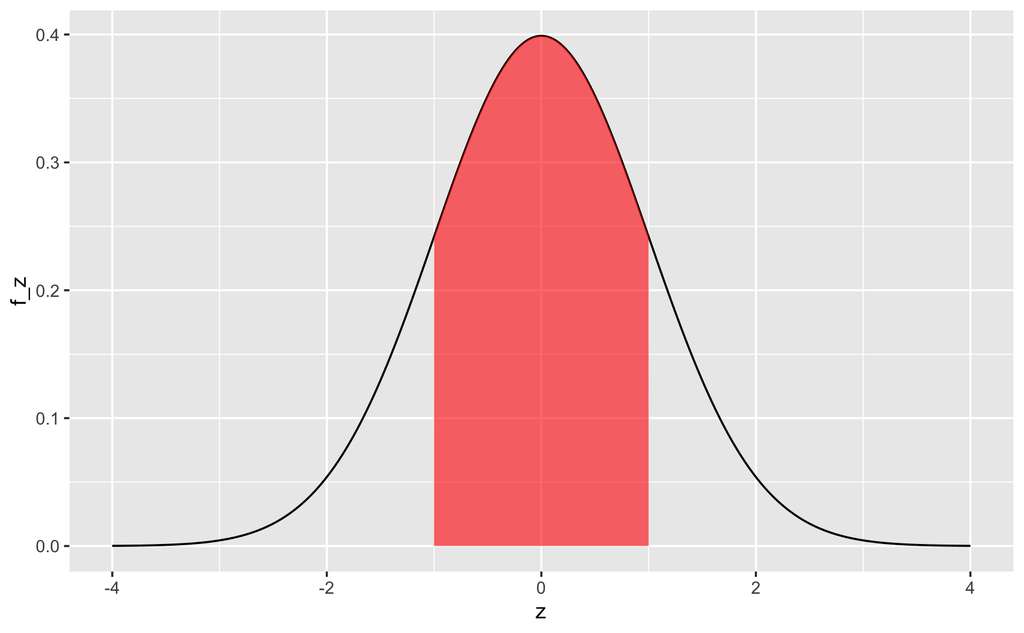

```r
shade_standard_normal(shade_from = -1, shade_to = 1)
```

most values lie with 3 sd dev of the mean let’s calculate how many values should lie within 1 sd of mean for a standard normal distribution

```r
# one st dev above - one sd dev below
100*(pnorm(q = 1) - pnorm(q = -1))
```

```
[1] 68.26895
```

68% of our data shoudl lie with in st dev of the mean

```r
100*(pnorm(q = 2) - pnorm(q = -2))
```

```
[1] 95.44997
```

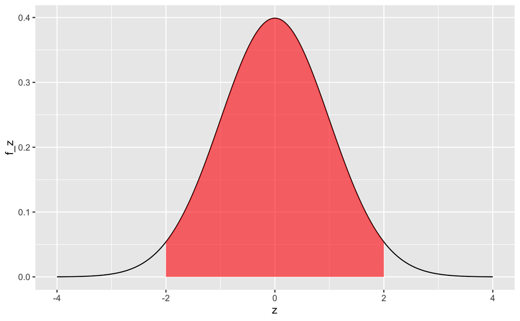

```r
shade_standard_normal(shade_from = -2, shade_to = 2)
```

```r
100*(pnorm(q = 3) - pnorm(q = -3))
```

```
[1] 99.73002
```